# Panel Data and Fixed Effects Methods for Ecology

The online tutorial for the analyses run in: Dee et al.

Last updated: 2021-04-02

## Setup and Load Data

```r
library(tidyverse)
library(data.table)
library(fixest)
library(lme4)  # 1.1-26
```

This data has already been cleaned and processed, and is ready to use. This data corresponds to what we use in the paper for the main analysis, and consists of control plots for NutNet sites. We include data from 43 NutNet sites. Each site includes one or more control plots that we use. We only use plots for which we have at least 5 years of data.

```r
cdir <- getwd()
comb <- fread(paste(cdir,"/cleaned_comb_data.csv",sep=""),na.strings='NA')
```

## Working through different approaches

For causal inference, we need to answer " if X changes, how much will Y change, on average,” with confidence that we have truly isolated a causal effect. Causal inference involves ruling out rival explanations for an estimated relationship, to interpret a correlation as a cause. This aim and requirement differs from other research aims (i.e., predicting where total productivity will be the highest, which can be done without knowing the true underlying causes of productivity). Thus, the criteria for evaluating causal inference differs from ways to evaluate analyses focused on prediction or forecasting, which instead use model fits, R-squared values, or mean square error (see Ferraro et al. 2018). Instead, causal inference is evaluated by assessing the credibility and validity of the assumptions made by an analysis design for each dataset, system, and research question (reviewed in Ferraro et al 2018), as we will illustrate next. h Therefore, being explicit about these assumptions and evaluating their likelihood of being met is important for causal inference. Doing so can improve estimates about relationships in nature, insights about the strength of causal relationships, and transparency in interpreting results.

### Simple correlations in single years

A first place to start is looking at simple correlations. We will examine both the overall correlation and correlations within a single year (i.e., using cross-sectional variation). We proceed in a linear regression framework, use log of productivity (measured as live aboveground biomass) as the outcome and log species richness as the explanatory variable. We’ve found that the log-log specification captures the nature of the relationship in our data well (see the paper for details), also following prior studies (REFs). That is, we estimate and report $\beta$ in:
$$\ln(\text{Live Mass}_{pst}) = \alpha + \beta \ln(\text{Richness}_{pst}) + e_{pst}$$
where $p$ indexes plots, $s$ indexes sites, and $t$ indexes years. The error term is captured by $e_{pst}$. We include a constant $\alpha$, but do not typically report it because we learn little from it.

We report results below using all years of data first, and then report results using two individual years: 2012 and 2013. Here, as everywhere below, we cluster standard errors by plot to reflect serial correlation in errors terms within a plot across years (we don’t to assume errors are iid). Note that when we use only a single year of data, this is equivalent to using heteroskedasticity-robust errors.

```r
SimpleCorrAll <- feols(log(live_mass) ~ log(rich), comb, cluster = "newplotid")

SimpleCorr2012 <- comb %>%
  filter(year==2012) %>%
  feols(log(live_mass) ~ log(rich), ., cluster = "newplotid")

SimpleCorr2013 <- comb %>%
  filter(year==2013) %>%
  feols(log(live_mass) ~ log(rich), ., cluster = "newplotid")

etable(SimpleCorrAll, SimpleCorr2012, SimpleCorr2013,
          cluster = "newplotid",
          drop = "Intercept",
          subtitles = c("Data All Years", "Data in 2012", "Data in 2013"))
```

```
##                   SimpleCorrAll  SimpleCorr2012      SimpleCorr2013
##                  Data All Years    Data in 2012        Data in 2013
## Dependent Var.:  log(live_mass)  log(live_mass)      log(live_mass)
##
## log(rich)       0.0647 (0.0953) 0.1897 (0.1703) -0.3766*** (0.1006)
## _______________ _______________ _______________ ___________________
## S.E.: Clustered   by: newplotid   by: newplotid       by: newplotid
## Observations              1,231             145                 121
## R2                      0.00129         0.00951             0.08045
## Adj. R2                 0.00048         0.00258             0.07272
```

As you can see in the results, including all years of data gives a non-significant positive relationship between productivity and richness. In just the 2012 data, the coefficient is larger in magnitude, but still insignificant. Finally, just using 2013 data, the coefficient switches signs and becomes significant.

So… which one to believe? Well, probably none of these, because they are all whack—we are not identifying the true causal relationship of richness on productivity. The variability of these results highlights that research designs that rely on non-experimental **cross-sectional** data often has problems with omitted variable bias.

When is $\beta$ identified? When there are no unobservables that are correlated with richness that also influence productivity. This assumption has a mathematical form: $\mathbb{E}[e_{pst} \times \ln(\text{Richness}_{pst})]=0$ (this is pretty similar to saying that $e_{pst}$ and $\ln(\text{Richness}_{pst})$ aren’t correlated). In the above results, there’s probably stuff in $e$ that is correlated with richness, like precipitation, disturbance, land-use history, soil characteristics, and other characteristics of sites and plots.

For our case, there are many variables that are correlated with biodiversity can also drive productivity (Fig. 1B – main text), creating the possibility for rival explanations and biased estimates for estimated effects from observations. For example, climatic conditions, soil nutrients, evolutionary history, and historic contingency during community assembly are all related to both productivity and biodiversity (Loreau 1998; Fukami & Nakajima 2011; Grace et al. 2016a). With a common driver of both variables that is not included in a model, two variables (i.e., biodiversity and an ecosystem function) may be correlated, even without a causal relationship between them.. Similarly, no correlation between variables does not imply a lack of causation. Causal relationships can also be masked when examining correlations, due to an omitted variable, e.g., omitting nitrogen addition, which positively affects productivity but negatively affects richness (Isbell et al. 2013). Models that do not control for that common driver will consequently tend to give estimates that do not correspond to causal effects of biodiversity on productivity (or vice versa).

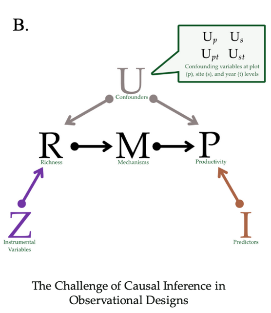

Figure 1B (main text – right panel) is known as a directed acyclic causal graph (DAG) and is a visualization of qualitative causal assumptions (Pearl 2009, 2011; Fieberg & Ditmer 2012; Schoolmaster et al. 2013, 2020). A DAG encodes knowledge and beliefs about how a system works. The graphical relations depicted in the DAG encode causal claims – not just representations of associations. A directed edge (e.g., R –> P) depicts a claim about the results of many hypothetical experiments, whereby if every other variable represented in the graph is held fixed, R and P will covary if R if manipulated, but not if P is manipulated (note, a DAG assumes that one can isolate the effect of R on P, but does not imply that P can never affect R; another DAG may represent the reverse direction, P –> R).